# machine-learning-project using pml training and testing data

## Summary and goal of the project:

The project use weight lifting data set from accelerometers on the belt, forearm, arm, and dumbell of 6 participants. They were asked to perform barbell lifts correctly and incorrectly in 5 different ways.

The goal of the project is to predict the manner in which participant did the exercise using “classe” variable in the training set. Create a report describing how model is build, how it is cross validated and report on out of sample error. Use this prediction model to predict 20 different test cases in test data set.

## Training and test data set

The training data used for the project is: https://d396qusza40orc.cloudfront.net/predmachlearn/pml-training.csv The test data are available here: https://d396qusza40orc.cloudfront.net/predmachlearn/pml-testing.csv The data for this project come from this source: http://groupware.les.inf.puc-rio.br/har

## Summary of raw training and testing data set and installing libraries for the project

```r
require(caret)
```

```r
require(corrplot)
require(randomForest)
```

In data there were lot of columns with NA and Div/0! showing missing values. So removing these columns and rows are important before we perform any analysis.

```r
train <- read.csv('pml-training.csv',header=TRUE,na.strings=c('#DIV/0!', '', 'NA'))
```

```r
test <- read.csv('pml-testing.csv',header=TRUE,na.strings=c('#DIV/0!', '', 'NA'))
```

We can check if ‘NA’ and ‘#Div/0! values are removed by sum(train==’#DIV/0!’, na.rm=TRUE)

```r
sum(test=='#DIV/0!',na.rm=TRUE)
```

```
## [1] 0
```

```r
sum(train=='#DIV/0!',na.rm=TRUE)
```

```
## [1] 0
```

Next we trim our columns, as columns with removed NA’s are blank and removing timestamp and user name data.

```r
dftrain<-train[, colSums(is.na(train))==0]
dftest<-test[, colSums(is.na(test))==0]
```

```r
dftrain<-subset(dftrain,select=c(8:60))

dftest<-subset(dftest,select=c(8:60))
```

We now split our clean training data into two parts training data and cross validation data.

```r
inTrain<-createDataPartition(y = dftrain$classe, p = 0.7, list = FALSE)
training<-dftrain[inTrain,]
validation<-dftrain[-inTrain,]
```

## Pre process data with PCA and visualizing correlation in training data. The reason for doing pca was it help in reducing predictor variables and getting same accuracy as training data with more variable.

To visualize correlation in data we have to find correlation between predictor variables

```r
M<-abs(cor(training[sapply(training, function(x) !is.factor(x))]))
```

To remove correlation with itself we use below function to put all the diagnol value to 0

```r
diag(M)<-0
```

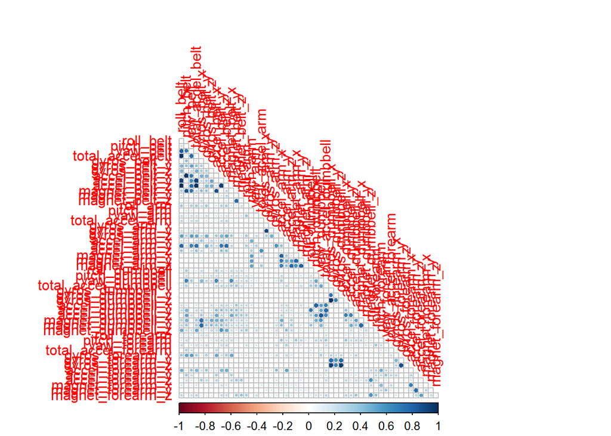

```r
corrplot(M,type="lower")
```

We pre-process our data using a principal component analysis in caret package, leaving out last column classe. After pre-processing we use ‘predict’ function to apply pca on test and training data.

```r
preProc<- preProcess(training[, -53], method = "pca", thresh = 0.99)
trainPC<-predict(preProc,training[,-53])
validPC<-predict(preProc,validation[,-53])
```

## Now use random forest to train the model on training data using classe variable. We have used randomForest instead of train function as train function takes more time.

```r
modelFit<-randomForest(training$classe ~.,data=trainPC,importance=TRUE)
```

## We can visualize the confusion matrix and variable importance from below functions. We have attached principal component importance plot in (prinComp.jpeg) file. The plot show principal componenets on Y-axis and accuracy in X-axis. Points with the highest accuracy are at the top.

```r
print(modelFit)
```

```
##
## Call:
##  randomForest(formula = training$classe ~ ., data = trainPC, importance = TRUE)
##                Type of random forest: classification
##                      Number of trees: 500
## No. of variables tried at each split: 6
##
##         OOB estimate of  error rate: 2.14%
## Confusion matrix:
##      A    B    C    D    E class.error
## A 3896    5    1    3    1 0.002560164
## B   62 2573   20    0    3 0.031978932
## C    5   30 2344   15    2 0.021702838
## D    4    3   81 2157    7 0.042184725
## E    3   15   16   18 2473 0.020594059
```

```r
importance(modelFit)
```

```
##             A        B        C        D        E MeanDecreaseAccuracy
## PC1  34.34367 50.81641 46.35202 46.12168 53.00869             55.51505
## PC2  39.33918 47.09939 40.58568 44.57530 47.97681             54.92939
## PC3  38.52548 36.17577 41.19792 37.53958 35.40610             40.01555
## PC4  21.32021 24.67197 25.39221 23.83181 20.73207             24.42113
## PC5  41.54524 46.84966 44.32754 47.39970 45.85696             53.66427
## PC6  37.40628 42.91114 41.92756 41.40032 42.84043             50.49585
## PC7  36.00225 46.03884 36.79319 41.82334 42.11438             53.77093
## PC8  41.84867 44.63376 53.80469 62.20150 46.73869             54.15157
## PC9  29.15974 45.68568 43.77861 36.44928 39.28709             41.31259
## PC10 27.72802 35.16784 35.60349 33.36583 35.42752             38.42864
## PC11 29.85748 39.91017 38.61890 39.99476 37.66218             46.06841
## PC12 43.87991 51.09407 53.74696 44.19272 46.81484             56.56825
## PC13 29.16942 38.14281 40.42320 36.64916 39.50671             44.99706
## PC14 47.41172 48.59630 50.71760 51.03173 50.94836             56.59693
## PC15 36.50898 43.64153 41.67036 37.19848 41.81184             48.94294
## PC16 29.00320 44.29654 38.62121 41.10886 37.17072             44.02282
## PC17 32.14270 39.64871 36.15541 38.31056 36.79133             44.79784
## PC18 28.03235 37.46465 37.06973 34.66231 34.46784             48.92182
## PC19 26.14543 38.01495 32.21528 37.75790 36.58406             42.88117
## PC20 35.53068 42.34510 46.41546 40.77808 39.87579             55.19670
## PC21 33.02177 34.20074 33.86762 33.04483 32.54185             37.21506
## PC22 23.19932 32.29361 32.82072 30.08411 30.73700             32.41105
## PC23 22.65518 23.26362 25.02402 23.53791 21.65666             26.37373
## PC24 28.24513 39.28117 32.90004 29.50437 35.21377             45.36344
## PC25 29.67291 31.40552 36.54741 32.36762 31.81970             37.20018
## PC26 28.03076 37.18634 38.27957 43.00258 35.99525             42.10296
## PC27 32.01962 36.84535 39.46829 36.99266 37.12035             57.04784
## PC28 34.04424 36.40614 36.85605 38.17659 31.01251             43.87361
## PC29 39.36135 39.64897 38.12790 36.41821 38.36508             51.43923
## PC30 28.91922 33.57881 33.47620 32.70977 31.85547             38.61024
## PC31 30.23843 32.72529 30.27818 27.65560 29.97577             53.37628
## PC32 23.54676 26.24980 30.57907 27.52585 25.69186             28.36166
## PC33 28.78450 33.75283 37.86925 29.66909 31.56330             42.49048
## PC34 35.96490 32.34711 37.89531 33.35781 33.76166             39.12389
## PC35 61.55040 50.50272 63.59853 51.23905 44.42177             63.87961
## PC36 34.23641 47.51111 47.54248 50.33372 35.36844             45.01694
##      MeanDecreaseGini
## PC1          473.3762
## PC2          353.8939
```

[output cut: 19 more lines]

```
## PC22         273.3071
## PC23         165.5647
## PC24         176.1408
## PC25         225.1818
## PC26         312.1709
## PC27         190.1290
## PC28         257.7690
## PC29         233.6186
## PC30         225.7319
## PC31         119.7484
## PC32         245.2941
## PC33         180.7305
## PC34         279.5449
## PC35         487.1909
## PC36         382.7593
```

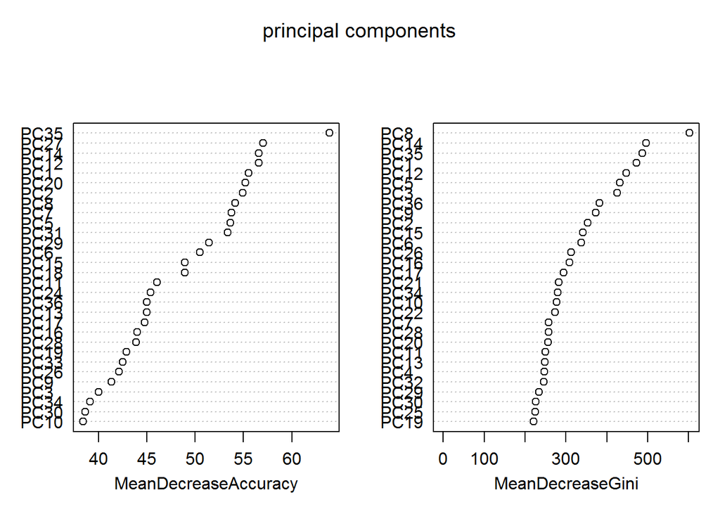

```r
varImpPlot(modelFit,sort=TRUE,main="principal components")
```

For validating model on validation data and how the model actually fit we predict our result on validation data.

```r
pred_valid<-predict(modelFit,validPC)

confusion<-confusionMatrix(validation$classe,pred_valid)

confusion$table
```

```
##           Reference
## Prediction    A    B    C    D    E
##          A 1667    5    0    2    0
##          B   22 1105    7    3    2
##          C    4   14  999    9    0
##          D    0    1   45  916    2
##          E    2    5    9   10 1056
```

## To find how much accurate our prediction is , we check accuracy and out of sample error of our model on vaildation data.

```r
accur <- postResample(validation$classe, pred_valid)
accur
```

```
##  Accuracy     Kappa
## 0.9758709 0.9694655
```

```r
outSamperror<-1-accur[[1]]
outSamperror
```

```
## [1] 0.02412914
```

## Final test on test data set, so first we pre-process our data set and remove last column of problem_id. We ran our result on test data set and predict result

```r
testPC <- predict(preProc, dftest[,-53])
predFinal <- predict(modelFit, testPC)
```

```r
predFinal
```

```
##  1  2  3  4  5  6  7  8  9 10 11 12 13 14 15 16 17 18 19 20
##  B  A  B  A  A  E  D  B  A  A  B  C  B  A  E  E  A  B  B  B
## Levels: A B C D E
```